# Project Foundations for Data Science: FoodHub Data Analysis

by Robert Swetland

**Marks: 40**

### Context

The number of restaurants in New York is increasing day by day. Lots of students and busy professionals rely on those restaurants due to their hectic lifestyles. Online food delivery service is a great option for them. It provides them with good food from their favorite restaurants. A food aggregator company FoodHub offers access to multiple restaurants through a single smartphone app.

The app allows the restaurants to receive a direct online order from a customer. The app assigns a delivery person from the company to pick up the order after it is confirmed by the restaurant. The delivery person then uses the map to reach the restaurant and waits for the food package. Once the food package is handed over to the delivery person, he/she confirms the pick-up in the app and travels to the customer's location to deliver the food. The delivery person confirms the drop-off in the app after delivering the food package to the customer. The customer can rate the order in the app. The food aggregator earns money by collecting a fixed margin of the delivery order from the restaurants.

### Objective

The food aggregator company has stored the data of the different orders made by the registered customers in their online portal. They want to analyze the data to get a fair idea about the demand of different restaurants which will help them in enhancing their customer experience. Suppose you are hired as a Data Scientist in this company and the Data Science team has shared some of the key questions that need to be answered. Perform the data analysis to find answers to these questions that will help the company to improve the business.

### Data Description

The data contains the different data related to a food order. The detailed data dictionary is given below.

### Data Dictionary

- order_id: Unique ID of the order
- customer_id: ID of the customer who ordered the food
- restaurant_name: Name of the restaurant
- cuisine_type: Cuisine ordered by the customer
- cost: Cost of the order
- day_of_the_week: Indicates whether the order is placed on a weekday or weekend (The weekday is from Monday to Friday and the weekend is Saturday and Sunday)
- rating: Rating given by the customer out of 5
- food_preparation_time: Time (in minutes) taken by the restaurant to prepare the food. This is calculated by taking the difference between the timestamps of the restaurant's order confirmation and the delivery person's pick-up confirmation.
- delivery_time: Time (in minutes) taken by the delivery person to deliver the food package. This is calculated by taking the difference between the timestamps of the delivery person's pick-up confirmation and drop-off information

### Let us start by importing the required libraries

```python
# Import libraries for data manipulation
import numpy as np
import pandas as pd

# Import libraries for data visualization
import matplotlib.pyplot as plt
import seaborn as sns

# Import libraries for statistical analysis
from scipy import stats
from scipy.stats import pearsonr
from scipy.stats import linregress

# Perform math
import math

import warnings
warnings.filterwarnings('ignore')

# Suppress future warnings
warnings.simplefilter(action='ignore', category=FutureWarning)

# Connect collab
from google.colab import drive
drive.mount('/content/drive')

# Load data from csv file
data = pd.read_csv('/content/drive/MyDrive/MIT - Data Sciences/Colab Notebooks/Week Two - Statistics for Data Science/Project Assessment - FoodHub/foodhub_order.csv')
```

### Understanding the structure of the data

```python
# returns the first 5 rows
data.head()
```

|  | order_id | customer_id | restaurant_name | cuisine_type | cost_of_the_order | day_of_the_week | rating | food_preparation_time | delivery_time |
| --- | --- | --- | --- | --- | --- | --- | --- | --- | --- |
| 0 | 1477147 | 337525 | Hangawi | Korean | 30.75 | Weekend | Not given | 25 | 20 |
| 1 | 1477685 | 358141 | Blue Ribbon Sushi Izakaya | Japanese | 12.08 | Weekend | Not given | 25 | 23 |
| 2 | 1477070 | 66393 | Cafe Habana | Mexican | 12.23 | Weekday | 5 | 23 | 28 |
| 3 | 1477334 | 106968 | Blue Ribbon Fried Chicken | American | 29.20 | Weekend | 3 | 25 | 15 |
| 4 | 1478249 | 76942 | Dirty Bird to Go | American | 11.59 | Weekday | 4 | 25 | 24 |

```python
# returns the last 5 rows
data.tail()
```

|  | order_id | customer_id | restaurant_name | cuisine_type | cost_of_the_order | day_of_the_week | rating | food_preparation_time | delivery_time |
| --- | --- | --- | --- | --- | --- | --- | --- | --- | --- |
| 1893 | 1476701 | 292602 | Chipotle Mexican Grill $1.99 Delivery | Mexican | 22.31 | Weekend | 5 | 31 | 17 |
| 1894 | 1477421 | 397537 | The Smile | American | 12.18 | Weekend | 5 | 31 | 19 |
| 1895 | 1477819 | 35309 | Blue Ribbon Sushi | Japanese | 25.22 | Weekday | Not given | 31 | 24 |
| 1896 | 1477513 | 64151 | Jack's Wife Freda | Mediterranean | 12.18 | Weekday | 5 | 23 | 31 |
| 1897 | 1478056 | 120353 | Blue Ribbon Sushi | Japanese | 19.45 | Weekend | Not given | 28 | 24 |

#### Observations:

The DataFrame has 9 columns as mentioned in the Data Dictionary. Data in each row corresponds to the order placed by a customer.

### **Question 1:** How many rows and columns are present in the data?

```python
# Determine the number of rows and columns by calling data.shape
data.shape
```

```
(1898, 9)
```

#### **Observations**:

The DataFrame contains:

- rows: 1898
- columns: 9

### **Question 2:** What are the datatypes of the different columns in the dataset? (The info() function can be used)

```python
# Use info() to print a concise summary of the DataFrame
data.info()
```

[output not shown]

#### **Observations**:

**Data Types Distribution:**

- There are 4 columns with integer data types (int64).
- There is 1 column with a float data type (float64).
- There are 4 columns with object data types (object), which typically represent string data.

These observations indicate a well-formed DataFrame with complete data and a mix of numerical and categorical data types.

### **Question 3:** Are there any missing values in the data? If yes, treat them using an appropriate method

#### **Observations**:

Each column has **1898** non-null entries, indicating that there are **no missing values** in any of the columns.

### **Question 4:** Check the statistical summary of the data. What is the minimum, average, and maximum time it takes for food to be prepared once an order is placed?

```python
# Check the statistical summary of the DataFrame
summary = data.describe()

# Minimum food preparation time
food_prep_min = data['food_preparation_time'].min()

# Average (mean) food preparation time
food_prep_avg = round(data['food_preparation_time'].mean(), 2)

# Maximum food preparation time
food_prep_max = data['food_preparation_time'].max()

# Format the summary using pandas Styler
summary_styled = summary.style.set_table_styles(
    [{'selector': 'thead th', 'props': [('background-color', '#f7f7f9'), ('color', '#333'), ('font-weight', 'bold')]}]
).set_properties(**{'text-align': 'center'})

# Display the styled summary
display(summary_styled)

# Create a DataFrame for the food preparation times
prep_times_df = pd.DataFrame({
    'Metric': ['Minimum', 'Average', 'Maximum'],
    'Food Preparation Time (minutes)': [food_prep_min, food_prep_avg, food_prep_max]
})

print("\n")

# Format the preparation times DataFrame using pandas Styler
prep_times_styled = prep_times_df.style.set_table_styles(
    [{'selector': 'thead th', 'props': [('background-color', '#f7f7f9'), ('color', '#333'), ('font-weight', 'bold')]}]
).set_properties(**{'text-align': 'center'})

# Display the styled preparation times DataFrame
display(prep_times_styled)
```

|  | order_id | customer_id | cost_of_the_order | food_preparation_time | delivery_time |
| --- | --- | --- | --- | --- | --- |
| count | 1898.000000 | 1898.000000 | 1898.000000 | 1898.000000 | 1898.000000 |
| mean | 1477495.500000 | 171168.478398 | 16.498851 | 27.371970 | 24.161749 |
| std | 548.049724 | 113698.139743 | 7.483812 | 4.632481 | 4.972637 |
| min | 1476547.000000 | 1311.000000 | 4.470000 | 20.000000 | 15.000000 |
| 25% | 1477021.250000 | 77787.750000 | 12.080000 | 23.000000 | 20.000000 |
| 50% | 1477495.500000 | 128600.000000 | 14.140000 | 27.000000 | 25.000000 |
| 75% | 1477969.750000 | 270525.000000 | 22.297500 | 31.000000 | 28.000000 |
| max | 1478444.000000 | 405334.000000 | 35.410000 | 35.000000 | 33.000000 |

|  | Metric | Food Preparation Time (minutes) |
| --- | --- | --- |
| 0 | Minimum | 20.000000 |
| 1 | Average | 27.370000 |
| 2 | Maximum | 35.000000 |

#### **Observations**:

Based on the statistical summary of the food_preparation_time column in the DataFrame, we can make the following observations:

- The **minimum time** it takes for food to be prepared once an order is placed is **20 minutes**.
- The **average** (mean) time for food preparation is **27.37 minutes**.
- The **maximum** time it takes for food to be prepared is **35 minutes**.

### **Question 5:** How many orders are not rated?

```python
# Count the number of non-rated orders

# Find unique values for data['rating'] column
unique  = data['rating'].unique()
print (unique)

# It appears non-rated orders are where data['rating'] = unique[0]
non_rated_orders = data[data['rating'] == unique[0]].shape[0]

print(f"Number of orders not rated: {non_rated_orders}")
```

```
['Not given' '5' '3' '4']
Number of orders not rated: 736
```

#### **Observations**:

Upon analyzing the rating column in the DataFrame, it was found that there are a total of **736** orders rated as '**Not given**'.

Interestingly there are not ratings lower than 3.

# **Exploratory Data Analysis (EDA)**

# Univariate Analysis

### **Question 6:** Explore all the variables and provide observations on their distributions. (Generally, histograms, boxplots, countplots, etc. are used for univariate exploration)

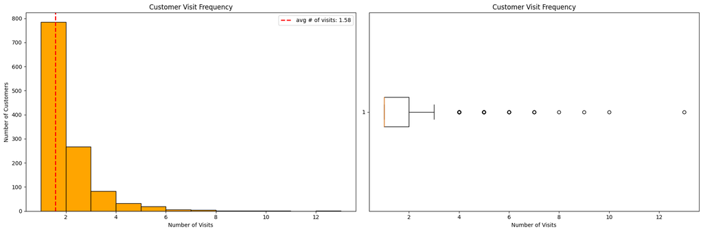

```python
# Examine the characteristics of each variable

# Analyze the distribution of customer_id

CID_Distribution = data['customer_id'].value_counts()
CID_max = CID_Distribution.max()    # Most frequent customer
CID_min = CID_Distribution.min()    # Least frequent customer(s)
CID_mean = CID_Distribution.mean()  # Average # of visits by customer

# count the number of customers that visited only once and calculate %
CID_once = (CID_Distribution == 1).sum()
CID_once_percent = round((CID_once / CID_Distribution.shape[0]) * 100, 2)

# Plotting the distribution
plt.figure(figsize=(18, 6))

# Histogram of customer visit frequency
plt.figure(figsize=(18, 6))

# Histogram of customer visit frequency
plt.subplot(1, 2, 1)
plt.hist(CID_Distribution, bins=range(1, CID_Distribution.max() + 1), edgecolor='black', color='orange')
plt.axvline(CID_mean, color='red', linestyle='dashed', linewidth=2, label=f'avg # of visits: {CID_mean:.2f}')
plt.title('Customer Visit Frequency')
plt.xlabel('Number of Visits')
plt.ylabel('Number of Customers')
plt.legend()

# Boxplot of customer visit frequency
plt.subplot(1, 2, 2)
plt.boxplot(CID_Distribution, vert=False)
plt.title('Customer Visit Frequency')
plt.xlabel('Number of Visits')

plt.tight_layout()
plt.show()
```

[figure not shown]

```python
# Analyze the distribution of restaurant_name

unique_restaurants = data['restaurant_name'].nunique()

# Analyze the distribution of orders per restaurant
restaurant_order_distribution = data['restaurant_name'].value_counts()
most_orders = restaurant_order_distribution.max()
least_orders = restaurant_order_distribution.min()
average_orders = restaurant_order_distribution.mean()

# Names of the most and least popular restaurants
most_popular_restaurant = restaurant_order_distribution.idxmax()
least_popular_restaurant = restaurant_order_distribution.idxmin()

# Count the number of restaurants with only 1 order
restaurants_with_one_order = (restaurant_order_distribution == 1).sum()

# Get the top 75 restaurants by number of orders (more than this will make the x axis labels illegible)
top_75_restaurants = restaurant_order_distribution.head(50)

# Visualize the distribution of orders for the top 75 restaurants
plt.figure(figsize=(18, 6))
top_75_restaurants.plot(kind='bar')
plt.title('Top 75 Restaurants by Number of Orders')
plt.xlabel('Restaurant Name')
plt.ylabel('Number of Orders')

# Rotate x-axis labels for better readability
plt.xticks(rotation=90, fontsize=8)
plt.show()

# Set display options for wider columns
pd.set_option('display.max_columns', None)
pd.set_option('display.width', 300)
pd.set_option('display.max_colwidth', None)
```

[output not shown]

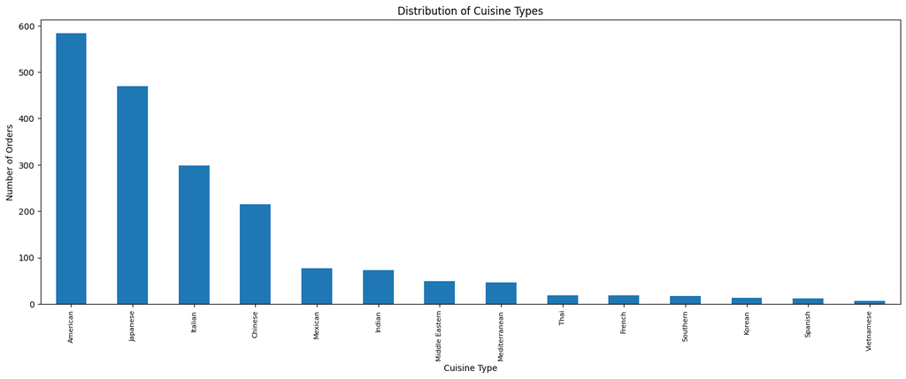

```python
# Analyze the distribution of cuisine types
cuisine_type_distribution = data['cuisine_type'].value_counts()

# Calculate the most and least popular cuisine types
most_popular_cuisine = cuisine_type_distribution.idxmax()
least_popular_cuisine = cuisine_type_distribution.idxmin()

# Visualize the distribution of cuisine types
plt.figure(figsize=(18, 6))
cuisine_type_distribution.plot(kind='bar')
plt.title('Distribution of Cuisine Types')
plt.xlabel('Cuisine Type')
plt.ylabel('Number of Orders')
plt.xticks(rotation=90, fontsize=8)
plt.show()
```

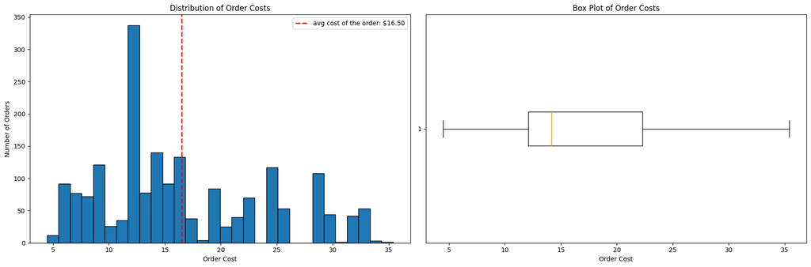

```python
# Analyze the distribution of order costs
order_cost_distribution = data['cost_of_the_order']

# Calculate the statistics
max_cost = order_cost_distribution.max()
min_cost = order_cost_distribution.min()
mean_cost = order_cost_distribution.mean()

# Create subplots
fig, axes = plt.subplots(nrows=1, ncols=2, figsize=(18, 6))

# Histogram of order costs with a vertical line for the mean cost
axes[0].hist(order_cost_distribution, bins=30, edgecolor='black')
axes[0].axvline(mean_cost, color='red', linestyle='dashed', linewidth=2, label=f'avg cost of the order: ${mean_cost:.2f}')
axes[0].set_title('Distribution of Order Costs')
axes[0].set_xlabel('Order Cost')
axes[0].set_ylabel('Number of Orders')
axes[0].legend()

# Box plot for the order costs
axes[1].boxplot(order_cost_distribution, vert=False)
axes[1].set_title('Box Plot of Order Costs')
axes[1].set_xlabel('Order Cost')

# Adjust layout
plt.tight_layout()
plt.show()
```

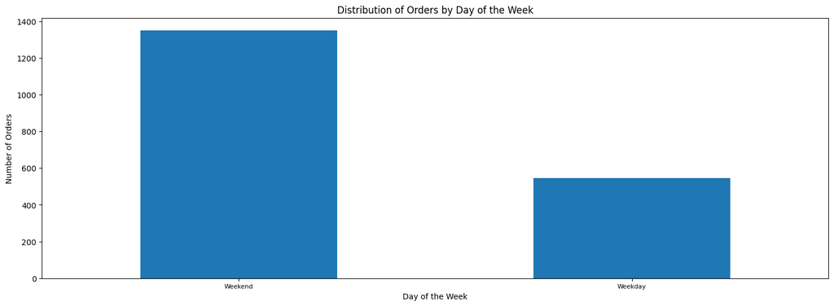

```python
# Analyze the distribution of orders by the day of the week
day_of_week_distribution = data['day_of_the_week'].value_counts()

# Visualize the distribution of orders by the day of the week
plt.figure(figsize=(18, 6))
day_of_week_distribution.plot(kind='bar')
plt.title('Distribution of Orders by Day of the Week')
plt.xlabel('Day of the Week')
plt.ylabel('Number of Orders')
plt.xticks(rotation=0, fontsize=8)
plt.show()
```

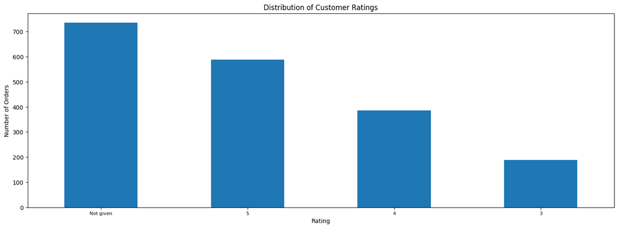

```python
# Analyze the distribution of ratings
rating_distribution = data['rating'].value_counts()

# Visualize the distribution of ratings
plt.figure(figsize=(18, 6))
rating_distribution.plot(kind='bar')
plt.title('Distribution of Customer Ratings')
plt.xlabel('Rating')
plt.ylabel('Number of Orders')
plt.xticks(rotation=0, fontsize=8)
plt.show()
```

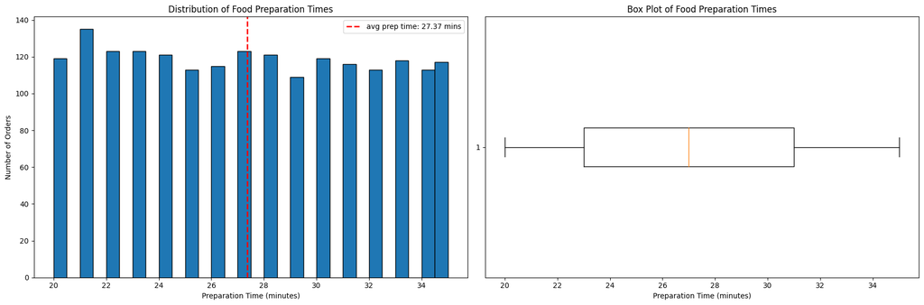

```python
# Analyze the distribution of food preparation times
prep_time_distribution = data['food_preparation_time']

# Calculate the statistics
max_prep_time = prep_time_distribution.max()
min_prep_time = prep_time_distribution.min()
mean_prep_time = prep_time_distribution.mean()

# Create subplots
fig, axes = plt.subplots(nrows=1, ncols=2, figsize=(18, 6))

# Histogram of food preparation times with a vertical line for the mean time
axes[0].hist(prep_time_distribution, bins=30, edgecolor='black')
axes[0].axvline(mean_prep_time, color='red', linestyle='dashed', linewidth=2, label=f'avg prep time: {mean_prep_time:.2f} mins')
axes[0].set_title('Distribution of Food Preparation Times')
axes[0].set_xlabel('Preparation Time (minutes)')
axes[0].set_ylabel('Number of Orders')
axes[0].legend()

# Box plot for the food preparation times
axes[1].boxplot(prep_time_distribution, vert=False)
axes[1].set_title('Box Plot of Food Preparation Times')
axes[1].set_xlabel('Preparation Time (minutes)')

# Adjust layout
plt.tight_layout()
plt.show()
```

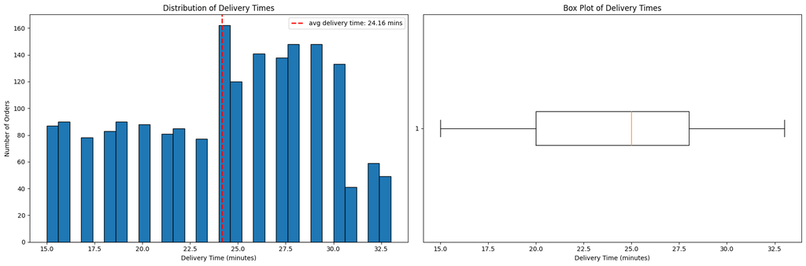

```python
# Analyze the distribution of delivery times
delivery_time_distribution = data['delivery_time']

# Calculate the statistics
max_delivery_time = delivery_time_distribution.max()
min_delivery_time = delivery_time_distribution.min()
mean_delivery_time = delivery_time_distribution.mean()

# Create subplots
fig, axes = plt.subplots(nrows=1, ncols=2, figsize=(18, 6))

# Histogram of delivery times with a vertical line for the mean time
axes[0].hist(delivery_time_distribution, bins=30, edgecolor='black')
axes[0].axvline(mean_delivery_time, color='red', linestyle='dashed', linewidth=2, label=f'avg delivery time: {mean_delivery_time:.2f} mins')
axes[0].set_title('Distribution of Delivery Times')
axes[0].set_xlabel('Delivery Time (minutes)')
axes[0].set_ylabel('Number of Orders')
axes[0].legend()

# Box plot for the delivery times
axes[1].boxplot(delivery_time_distribution, vert=False)
axes[1].set_title('Box Plot of Delivery Times')
axes[1].set_xlabel('Delivery Time (minutes)')

# Adjust layout
plt.tight_layout()
plt.show()
```

### **Question 7**: Which are the top 5 restaurants in terms of the number of orders received?

```python
# Get the top 5 restaurants by number of orders
top_5_restaurants = restaurant_order_distribution.head(5)
#top_5_restaurants

# Convert the series to a DataFrame for better formatting
top_5_restaurants_df = top_5_restaurants.reset_index()
top_5_restaurants_df.columns = ['Restaurant Name', 'Number of Orders']

# Convert the series to a DataFrame for better formatting
top_5_restaurants_df = top_5_restaurants.reset_index()
top_5_restaurants_df.columns = ['Restaurant Name', 'Number of Orders']

# Format the table using pandas Styler
top_5_restaurants_styled = top_5_restaurants_df.style.set_caption("Top 5 Restaurants by Number of Orders<br><br>").set_table_styles(
    [{'selector': 'caption', 'props': [('caption-side', 'top'), ('font-size', '16px'), ('font-weight', 'bold'), ('text-align', 'center')]},
     {'selector': 'thead th', 'props': [('background-color', '#f7f7f9'), ('color', '#333'), ('font-weight', 'bold')]}]
).set_properties(subset=['Restaurant Name'], **{'text-align': 'left'}).set_properties(subset=['Number of Orders'], **{'text-align': 'center'}).hide(axis="index")

# Display the styled table
top_5_restaurants_styled
```

Top 5 Restaurants by Number of Orders

| Restaurant Name | Number of Orders |
| --- | --- |
| Shake Shack | 219 |
| The Meatball Shop | 132 |
| Blue Ribbon Sushi | 119 |
| Blue Ribbon Fried Chicken | 96 |
| Parm | 68 |

#### **Observations**:

**Dominance of Shake Shack**:

- **Shake Shack** leads significantly with **219 orders**, indicating its high popularity among customers.

**Significant Order Volumes**:

- The Meatball Shop and Blue Ribbon Sushi are also quite popular, with 132 and 119 orders respectively, but they trail behind Shake Shack by a notable margin.

**Diverse Cuisine Types**:

- The top 5 restaurants represent a variety of cuisines, including American fast food (Shake Shack), Italian (The Meatball Shop, Parm), and Japanese (Blue Ribbon Sushi).
- This variety reflects a broad range of customer preferences. Distribution Drop-off:
- There is a noticeable drop in the number of orders from the third to the fifth restaurant, showing a significant difference in popularity among the top restaurants.

### **Question 8**: Which is the most popular cuisine on weekends?

```python
# Filter the data for weekends
weekend_data = data[data['day_of_the_week'] == 'Weekend']

# Analyze the distribution of cuisine types on weekends
weekend_cuisine_distribution = weekend_data['cuisine_type'].value_counts()

# Get the most popular cuisine on weekends
most_popular_cuisine_weekend = weekend_cuisine_distribution.idxmax()
most_popular_cuisine_count = weekend_cuisine_distribution.max()

# Get the second most popular cuisine on weekends (for comparison)
second_most_popular_cuisine_weekend = weekend_cuisine_distribution.index[1]
second_most_popular_cuisine_count = weekend_cuisine_distribution.iloc[1]

# Create a DataFrame for the most popular weekend cuisine
most_popular_cuisine_df = pd.DataFrame({
    'Cuisine Type': [most_popular_cuisine_weekend],
    'Number of Orders': [most_popular_cuisine_count]
})

# Format the table using pandas Styler
most_popular_cuisine_styled = most_popular_cuisine_df.style.set_caption("Most Popular Cuisine on Weekends<br><br>").set_table_styles(
    [{'selector': 'caption', 'props': [('caption-side', 'top'), ('font-size', '16px'), ('font-weight', 'bold'), ('text-align', 'center')]},
     {'selector': 'thead th', 'props': [('background-color', '#f7f7f9'), ('color', '#333'), ('font-weight', 'bold')]}]
).set_properties(subset=['Cuisine Type'], **{'text-align': 'left'}).set_properties(subset=['Number of Orders'], **{'text-align': 'center'}).hide(axis="index")

# Display the styled table
most_popular_cuisine_styled
```

Most Popular Cuisine on Weekends

| Cuisine Type | Number of Orders |
| --- | --- |
| American | 415 |

#### **Observations**:

**Most Popular Cuisine**:

**High Volume of Orders**:

The number of orders for the most popular cuisine on weekends is significantly high, showing that weekends are a busy time for American cuisine.

**Customer Preferences**:

The popularity of American cuisine on weekends might be due to the types of meals associated with this cuisine, such as burgers, fries, and other fast food items, which are often considered comfort or leisure food.

### **Question 9**: What percentage of the orders cost more than 20 dollars?

```python
# Calculate the percentage of orders that cost more than 20 dollars
total_orders = data.shape[0]
orders_above_20 = data[data['cost_of_the_order'] > 20].shape[0]
percentage_above_20 = (orders_above_20 / total_orders) * 100

# Print the result
print(f"Percentage of orders that cost more than 20 dollars: {percentage_above_20:.2f}%")
```

```
Percentage of orders that cost more than 20 dollars: 29.24%
```

#### **Observations**:

The analysis reveals that a significant proportion (**29.24%**) of **orders exceed $20**, providing valuable insights into customer spending behavior and opportunities for revenue optimization. Restaurants can leverage this information to enhance their pricing strategies, marketing efforts, and overall customer experience.

### **Question 10**: What is the mean order delivery time?

```python
# Prevoiusly calculate mean_delivery_time
print("The mean order delivery time is %.2f minutes." % mean_delivery_time)
```

```
The mean order delivery time is 24.16 minutes.
```

#### Observations:

The analysis reveals that the **mean delivery time** for orders is approximately **24.16 minutes**.

This information is useful for understanding operational efficiency, setting customer expectations, and identifying areas for potential improvement in the delivery process.

### **Question 11:** The company has decided to give 20% discount vouchers to the top 3 most frequent customers. Find the IDs of these customers and the number of orders they placed

```python
# Top three customers using the previously calculate Customer ID Distribution
top_3_customers = CID_Distribution.head(3).reset_index()
top_3_customers.columns = ['Customer ID', 'Number of Orders']

# Format the table using pandas Styler
top_3_customers_styled = top_3_customers.style.set_caption("Top 3 Customers by Number of Orders<br><br>").set_table_styles(
    [{'selector': 'caption', 'props': [('caption-side', 'top'), ('font-size', '16px'), ('font-weight', 'bold'), ('text-align', 'center')]},
     {'selector': 'thead th', 'props': [('background-color', '#f7f7f9'), ('color', '#333'), ('font-weight', 'bold')]}]
).set_properties(subset=['Customer ID'], **{'text-align': 'left'}).set_properties(subset=['Number of Orders'], **{'text-align': 'center'}).hide(axis="index")

# Display the styled table
top_3_customers_styled
```

Top 3 Customers by Number of Orders

| Customer ID | Number of Orders |
| --- | --- |
| 52832 | 13 |
| 47440 | 10 |
| 83287 | 9 |

#### **Observations**:

# Multivariate Analysis

### **Question 12**: Perform a multivariate analysis to explore relationships between the important variables in the dataset. (It is a good idea to explore relations between numerical variables as well as relations between numerical and categorical variables)

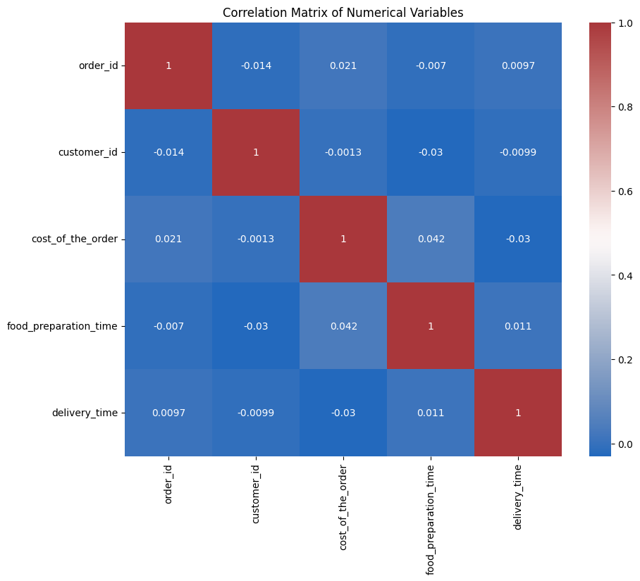

```python
# Correlation matrix of numerical variables

# Select only numerical columns
numerical_data = data.select_dtypes(include=['float64', 'int64'])

# Calculate the correlation matrix
corr_matrix = numerical_data.corr()

# Plot the heatmap
plt.figure(figsize=(10, 8))
sns.heatmap(corr_matrix, annot=True, cmap='vlag')
plt.title('Correlation Matrix of Numerical Variables')
plt.show()
```

### **Observations**

**Relationship Between Food Preparation Time and Delivery Time**:

**Cost of Order and Delivery Time**:

**Summary**:

# **Customer Behavior Analysis**

- Customer Order Frequency
  - Frequency of orders per customer
  - Average order value per customer
- Repeat Customer Analysis
  - Percentage of repeat customers
  - Average rating and order cost for repeat customers vs one-time customers

## Frequency of orders per customer

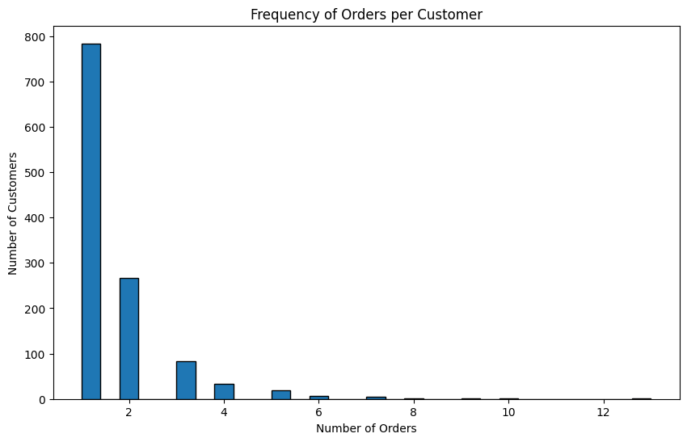

```
Pearson Correlation Score between 'cost_of_the_order' and 'delivery_time': -0.030
```

```python
# Calculate the frequency of orders per customer
order_frequency = data['customer_id'].value_counts().reset_index()
order_frequency.columns = ['customer_id', 'order_count']

# Style the table using pandas Styler
styled_table = order_frequency.style.background_gradient(cmap='viridis').set_caption("Frequency of Orders per Customer")

# Display the styled table
styled_table

# Plotting the frequency of orders per customer
plt.figure(figsize=(10, 6))
plt.hist(order_frequency['order_count'], bins=30, edgecolor='black')
plt.title('Frequency of Orders per Customer')
plt.xlabel('Number of Orders')
plt.ylabel('Number of Customers')
plt.show()

# Pearson correlation between 'cost_of_the_order' and 'delivery_time'
correlation_score = data['cost_of_the_order'].corr(data['delivery_time'])
print(f"Pearson Correlation Score between 'cost_of_the_order' and 'delivery_time': {correlation_score:.3f}")
```

## **Observations**

**Frequency of Orders per Customer**

- Distribution of Orders:
  - The histogram indicates that the majority of customers place a relatively low number of orders, while a few customers place orders more frequently.
  - This suggests that a small number of highly engaged customers drive a significant portion of sales, which is a common trend in many businesses.

**Pearson Correlation**

- Cost of the Order vs. Delivery Time:
  - The Pearson correlation score between cost_of_the_order and delivery_time is approximately -0.030.
  - This very weak negative correlation indicates that there is no significant linear relationship between the cost of an order and its delivery time in this dataset.
  - This implies that delivery times are relatively consistent regardless of the order cost, suggesting other factors might be influencing delivery time.

## Average order value per customer

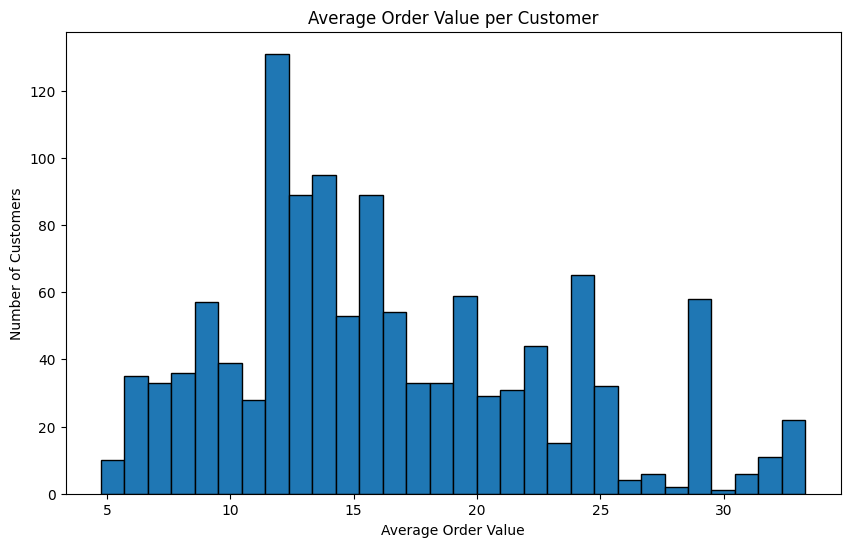

```python
# Calculate the average order value per customer
average_order_value = data.groupby('customer_id')['cost_of_the_order'].mean().reset_index()
average_order_value.columns = ['customer_id', 'average_order_value']

# Style the table using pandas Styler
styled_average_order_value = average_order_value.style.background_gradient(cmap='viridis').set_caption("Average Order Value per Customer")

# Display the styled table
styled_average_order_value

# Plotting the average order value per customer
plt.figure(figsize=(10, 6))
plt.hist(average_order_value['average_order_value'], bins=30, edgecolor='black')
plt.title('Average Order Value per Customer')
plt.xlabel('Average Order Value')
plt.ylabel('Number of Customers')
plt.show()
```

## **Observations**

**Average Order Value per Customer**

- Distribution of Average Order Values:
  - The histogram shows the distribution of average order values per customer. Most customers have a lower average order value, with fewer customers having higher average order values.
  - This trend indicates that a majority of customers tend to place orders of smaller amounts, while a smaller group of customers contributes to higher-value orders.
- Customer Spending Patterns:
  - Identifying the customers with higher average order values can help in tailoring marketing strategies to retain and engage these high-value customers.
  - Conversely, understanding why most customers place smaller orders might reveal opportunities for upselling or bundling products to increase the average order value.

## Percentage of repeat customers

```
Percentage of Repeat Customers: 34.67%
```

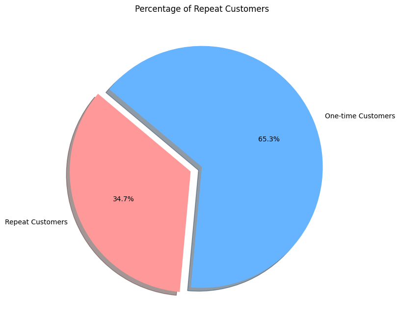

```python
# Calculate the percentage of repeat customers
total_customers = data['customer_id'].nunique()
repeat_customers = data['customer_id'].value_counts()[data['customer_id'].value_counts() > 1].count()
percentage_repeat_customers = (repeat_customers / total_customers) * 100

# Display the percentage of repeat customers
print(f"Percentage of Repeat Customers: {percentage_repeat_customers:.2f}%")

# Plotting the percentage of repeat customers
labels = ['Repeat Customers', 'One-time Customers']
sizes = [percentage_repeat_customers, 100 - percentage_repeat_customers]
colors = ['#ff9999','#66b3ff']
explode = (0.1, 0)  # explode the first slice

plt.figure(figsize=(8, 8))
plt.pie(sizes, explode=explode, labels=labels, colors=colors, autopct='%1.1f%%', shadow=True, startangle=140)
plt.title('Percentage of Repeat Customers')
plt.show()
```

## **Observations**

- **Repeat Customer Rate**:
  - Approximately one-third of the customers are repeat customers. This indicates a good level of customer retention and loyalty.

## Average rating and order cost for repeat customers vs one-time customers

```
Average Rating for Repeat Customers: 4.34
Average Order Cost for Repeat Customers: $16.49
Average Rating for One-time Customers: 4.35
Average Order Cost for One-time Customers: $16.52
```

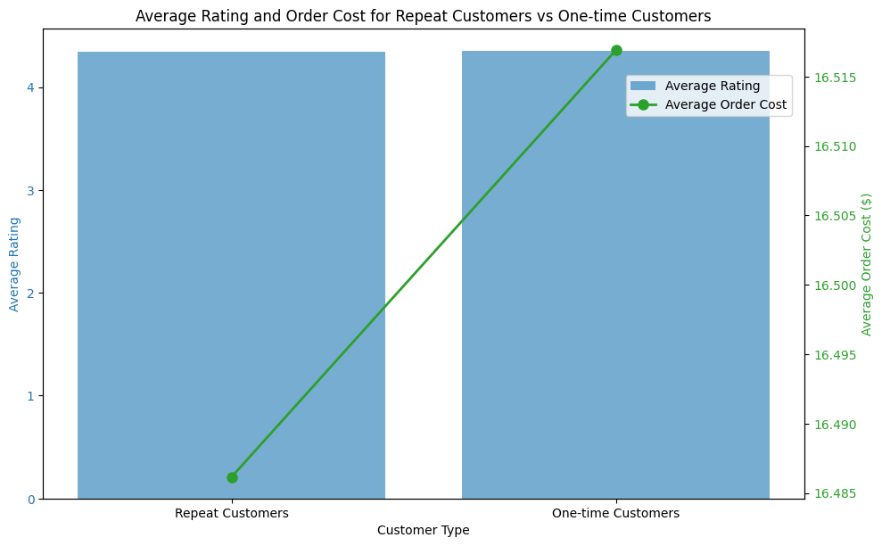

```python
# Identify repeat and one-time customers
repeat_customers_ids = data['customer_id'].value_counts()[data['customer_id'].value_counts() > 1].index
one_time_customers_ids = data['customer_id'].value_counts()[data['customer_id'].value_counts() == 1].index

# Separate data for repeat and one-time customers
repeat_customers_data = data[data['customer_id'].isin(repeat_customers_ids)]
one_time_customers_data = data[data['customer_id'].isin(one_time_customers_ids)]

# Calculate average rating and order cost for repeat customers
repeat_customers_avg_rating = repeat_customers_data[repeat_customers_data['rating'] != 'Not given']['rating'].astype(float).mean()
repeat_customers_avg_order_cost = repeat_customers_data['cost_of_the_order'].mean()

# Calculate average rating and order cost for one-time customers
one_time_customers_avg_rating = one_time_customers_data[one_time_customers_data['rating'] != 'Not given']['rating'].astype(float).mean()
one_time_customers_avg_order_cost = one_time_customers_data['cost_of_the_order'].mean()

# Display the results
print(f"Average Rating for Repeat Customers: {repeat_customers_avg_rating:.2f}")
print(f"Average Order Cost for Repeat Customers: ${repeat_customers_avg_order_cost:.2f}")
print(f"Average Rating for One-time Customers: {one_time_customers_avg_rating:.2f}")
print(f"Average Order Cost for One-time Customers: ${one_time_customers_avg_order_cost:.2f}")

# Plotting the results
categories = ['Repeat Customers', 'One-time Customers']
avg_ratings = [repeat_customers_avg_rating, one_time_customers_avg_rating]
avg_order_costs = [repeat_customers_avg_order_cost, one_time_customers_avg_order_cost]

fig, ax1 = plt.subplots(figsize=(10, 6))

color = 'tab:blue'
ax1.set_xlabel('Customer Type')
ax1.set_ylabel('Average Rating', color=color)
ax1.bar(categories, avg_ratings, color=color, alpha=0.6, label='Average Rating')
ax1.tick_params(axis='y', labelcolor=color)

ax2 = ax1.twinx()
color = 'tab:green'
ax2.set_ylabel('Average Order Cost ($)', color=color)
ax2.plot(categories, avg_order_costs, color=color, marker='o', linestyle='-', linewidth=2, markersize=8, label='Average Order Cost')
ax2.tick_params(axis='y', labelcolor=color)

fig.tight_layout()
plt.title('Average Rating and Order Cost for Repeat Customers vs One-time Customers')
fig.legend(loc='upper right', bbox_to_anchor=(0.9,0.9))
plt.show()
```

## **Observations**

**Average Rating**:

- The average rating for both repeat and one-time customers is very close, around 4.34 and 4.35 respectively, indicating similar satisfaction levels.

**Average Order Cost**:

- The average order cost for repeat customers is $16.49 $16.49 and for one-time customers is $16.52 This suggests that there isn't a significant difference in spending behavior between the two groups.

# **Cost Analysis**

- Order Cost by Cuisine Type
- Avg Cost by Day of the Week and Cuisine Type
- Order Frequency by Weekday/Weekend and Cuisine Type
- Order Cost by Preparation Time, Delivery Time and Total Time
- Order Frequency by Order Cost

## Order Cost by Cuisine Type

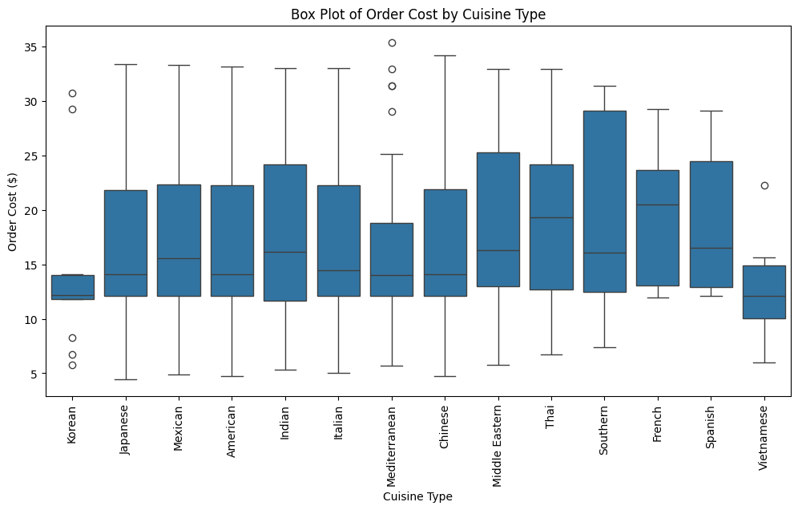

```
Pearson correlation coefficient between encoded cuisine type and order cost: 0.04
```

```python
# Box Plot of Order Cost by Cuisine Type

plt.figure(figsize=(12, 6))
sns.boxplot(x='cuisine_type', y='cost_of_the_order', data=data)
plt.title('Box Plot of Order Cost by Cuisine Type')
plt.xlabel('Cuisine Type')
plt.ylabel('Order Cost ($)')
plt.xticks(rotation=90)
plt.show()

# Encode the 'cuisine_type' column
data['cuisine_type_encoded'] = data['cuisine_type'].astype('category').cat.codes

# Calculate the Pearson correlation coefficient between encoded cuisine type and order cost
correlation_cost_cuisine = data['cuisine_type_encoded'].corr(data['cost_of_the_order'])

# Print the Pearson correlation coefficient
print(f"Pearson correlation coefficient between encoded cuisine type and order cost: {correlation_cost_cuisine:.2f}")
```

## **Observations**

The **very weak correlation** between cuisine type and order cost indicates that, while there may be some variation in costs among different cuisines, the overall impact of cuisine type on order cost is minimal. Other factors are likely more significant in determining the cost of an order.

## Avgerage Cost by Day of the Week and Cuisine Type

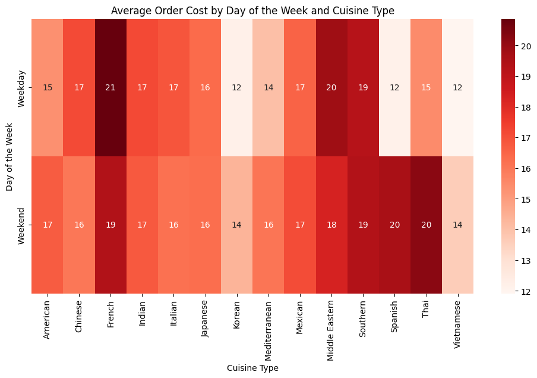

```
Pearson correlation coefficient between encoded cuisine type and order cost: 0.04
```

```python
# Create a pivot table for average order cost by day of the week and cuisine type
pivot_table = data.pivot_table(values='cost_of_the_order', index='day_of_the_week', columns='cuisine_type', aggfunc='mean')

# Visualize the pivot table as a heatmap
plt.figure(figsize=(12, 6))
sns.heatmap(pivot_table, annot=True, cmap='Reds')
plt.title('Average Order Cost by Day of the Week and Cuisine Type')
plt.xlabel('Cuisine Type')
plt.ylabel('Day of the Week')
plt.show()

# Manually encode the 'cuisine_type' column
data['cuisine_type_encoded'] = data['cuisine_type'].astype('category').cat.codes

# Calculate the Pearson correlation coefficient between encoded cuisine type and order cost
correlation = data['cuisine_type_encoded'].corr(data['cost_of_the_order'])

# Print the result
print(f"Pearson correlation coefficient between encoded cuisine type and order cost: {correlation:.2f}")
```

## **Observations**

**Summary**:

- Pearson Correlation Coefficient: 0.04
- Strength of Correlation: Negligible (0.00 to 0.10: Negligible correlation)

## Order Frequency by Weekday/Weekend and Cuisine Type

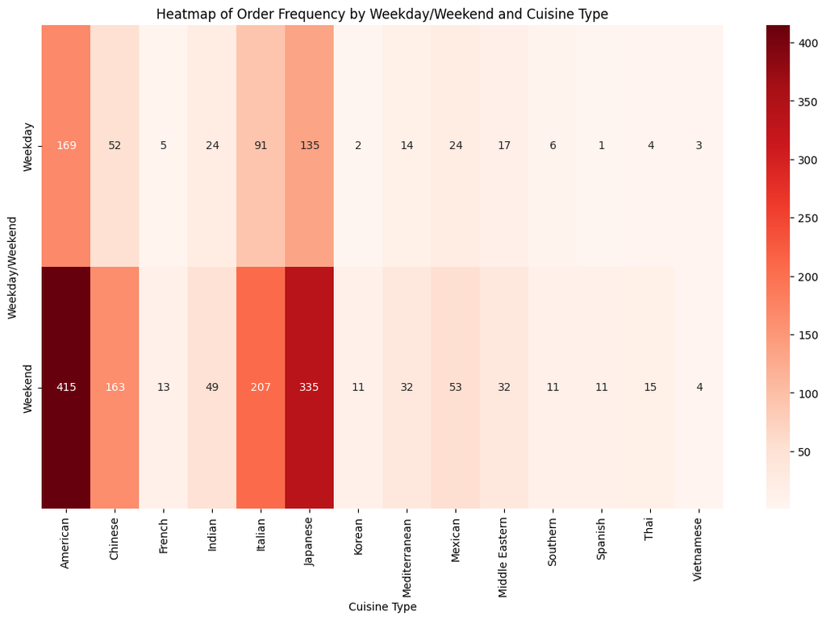

```python
# Create a pivot table for order frequency by Weekday and Weekend and cuisine type
order_frequency = data.pivot_table(values='order_id', index='day_of_the_week', columns='cuisine_type', aggfunc='count')

# Visualize the heatmap with adjusted plot width to avoid using exponents
plt.figure(figsize=(14, 8))
sns.heatmap(order_frequency, annot=True, fmt='d', cmap='Reds')
plt.title('Heatmap of Order Frequency by Weekday/Weekend and Cuisine Type')
plt.xlabel('Cuisine Type')
plt.ylabel('Weekday/Weekend')
plt.show()
```

## **Observations**

**Higher Order Frequencies on Weekends**:

- The heatmap shows that the order frequencies are generally higher on Weekends compared to Weekdays across various cuisine types.
- For example, American, Chinese, Italian and Japanese cuisines have appreciably higher order frequencies on Weekends.

**Popular Cuisine Types**:

- American and Japanese cuisine has the highest order frequency on both Weekdays and Weekends.
- Chinese and Italian cuisines also show high order frequencies, especially on Weekends.

**Consistent Popularity**:

- American, Italian and Japanese cuisines maintain relatively high order frequencies throughout both Weekdays and Weekends, indicating steady demand for these cuisines.

**Less Popular Cuisines**:

- Cuisines like French, Southern, Thai, and Vietnamese have lower order frequencies across both Weekdays and Weekends.
- These cuisines might have a niche customer base or less overall demand.

**Weekday vs Weekend Trends**:

- There is a noticeable increase in order frequencies for many cuisines on Weekends compared to Weekdays. This indicates a higher demand for food delivery services during weekends.

## Order Cost by Preparation Time, Delivery Time and Total Time

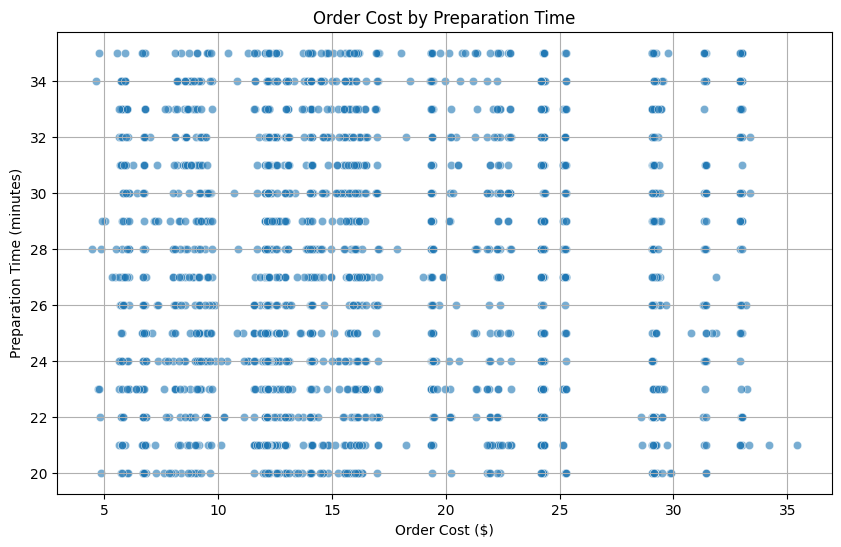

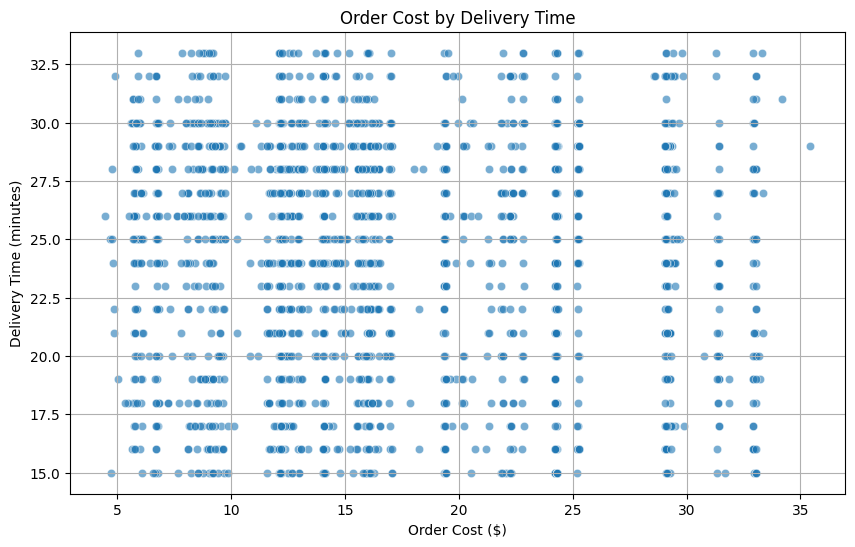

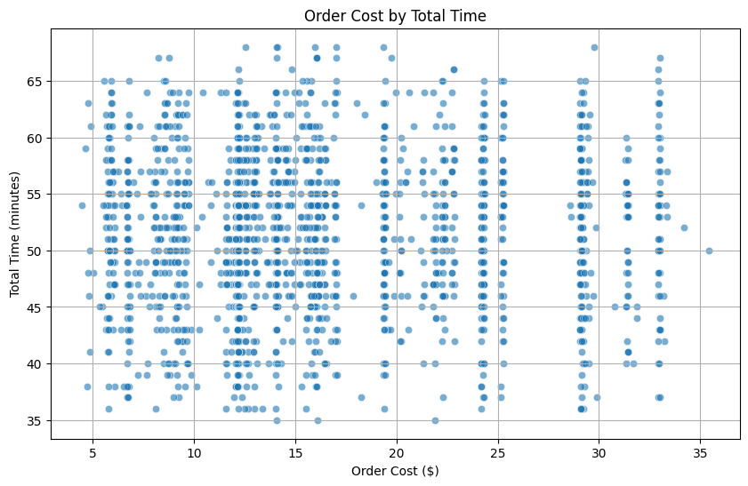

```
Pearson Correlation Score between 'cost_of_the_order' and 'food_preparation_time': 0.042
Pearson Correlation Score between 'cost_of_the_order' and 'delivery_time': -0.030
Pearson Correlation Score between 'cost_of_the_order' and 'total_time': 0.006
```

```python
# Calculate total time (preparation time + delivery time)
data['total_time'] = data['food_preparation_time'] + data['delivery_time']

# Plotting Order Cost by Preparation Time
plt.figure(figsize=(10, 6))
plt.scatter(data['cost_of_the_order'], data['food_preparation_time'], alpha=0.6, edgecolors='w', linewidth=0.5)
plt.title('Order Cost by Preparation Time')
plt.xlabel('Order Cost ($)')
plt.ylabel('Preparation Time (minutes)')
plt.grid(True)
plt.show()

# Plotting Order Cost by Delivery Time
plt.figure(figsize=(10, 6))
plt.scatter(data['cost_of_the_order'], data['delivery_time'], alpha=0.6, edgecolors='w', linewidth=0.5)
plt.title('Order Cost by Delivery Time')
plt.xlabel('Order Cost ($)')
plt.ylabel('Delivery Time (minutes)')
plt.grid(True)
plt.show()

# Plotting Order Cost by Total Time
plt.figure(figsize=(10, 6))
plt.scatter(data['cost_of_the_order'], data['total_time'], alpha=0.6, edgecolors='w', linewidth=0.5)
plt.title('Order Cost by Total Time')
plt.xlabel('Order Cost ($)')
plt.ylabel('Total Time (minutes)')
plt.grid(True)
plt.show()

# Calculate Pearson correlation scores
pearson_cost_prep_time = data['cost_of_the_order'].corr(data['food_preparation_time'])
pearson_cost_delivery_time = data['cost_of_the_order'].corr(data['delivery_time'])
pearson_cost_total_time = data['cost_of_the_order'].corr(data['total_time'])

print(f"Pearson Correlation Score between 'cost_of_the_order' and 'food_preparation_time': {pearson_cost_prep_time:.3f}")
print(f"Pearson Correlation Score between 'cost_of_the_order' and 'delivery_time': {pearson_cost_delivery_time:.3f}")
print(f"Pearson Correlation Score between 'cost_of_the_order' and 'total_time': {pearson_cost_total_time:.3f}")
```

## **Observations**

**Pearson Correlation Scores**

**Scatter Plots**

- Order Cost by Preparation Time:
  - The scatter plot shows a dispersed pattern with no clear trend, indicating that both low-cost and high-cost orders can have a wide range of preparation times.
- Order Cost by Delivery Time:
  - The scatter plot again shows a dispersed pattern with no clear trend, suggesting that delivery times are not significantly influenced by the cost of the order.
- Order Cost by Total Time:
  - The scatter plot shows a dispersed pattern with no clear trend, indicating that the total time (preparation + delivery) does not significantly correlate with the cost of the order.

## Order Frequency by Cost

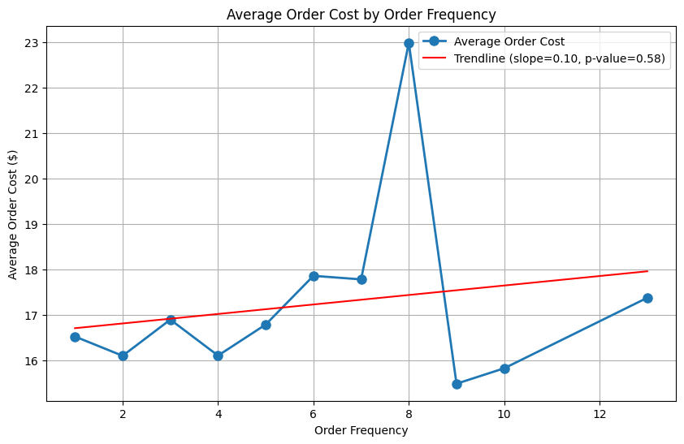

```
Pearson Correlation Score between 'order_count' and 'average_order_cost': 0.186
```

```python
from scipy.stats import linregress

# Calculate the frequency of orders per customer
order_frequency = data['customer_id'].value_counts().reset_index()
order_frequency.columns = ['customer_id', 'order_count']

# Merge the order frequency with the original dataset to get order costs
merged_data = pd.merge(data, order_frequency, on='customer_id')

# Calculate the average order cost for different order frequencies
avg_cost_by_frequency = merged_data.groupby('order_count')['cost_of_the_order'].mean().reset_index()
avg_cost_by_frequency.columns = ['order_count', 'average_order_cost']

# Style the table using pandas Styler
styled_avg_cost_by_frequency = avg_cost_by_frequency.style.background_gradient(cmap='viridis').set_caption("Average Order Cost by Order Frequency")

# Display the styled table
styled_avg_cost_by_frequency

# Plotting the average order cost by order frequency with trendline
plt.figure(figsize=(10, 6))
plt.plot(avg_cost_by_frequency['order_count'], avg_cost_by_frequency['average_order_cost'], marker='o', linestyle='-', linewidth=2, markersize=8, label='Average Order Cost')

# Add a trendline
slope, intercept, r_value, p_value, std_err = linregress(avg_cost_by_frequency['order_count'], avg_cost_by_frequency['average_order_cost'])
plt.plot(avg_cost_by_frequency['order_count'], intercept + slope * avg_cost_by_frequency['order_count'], 'r', label=f'Trendline (slope={slope:.2f}, p-value={p_value:.2f})')

plt.title('Average Order Cost by Order Frequency')
plt.xlabel('Order Frequency')
plt.ylabel('Average Order Cost ($)')
plt.legend()
plt.grid(True)
plt.show()

# Display the results
#print(avg_cost_by_frequency)

# Pearson correlation for detailed analysis
correlation_score = avg_cost_by_frequency['order_count'].corr(avg_cost_by_frequency['average_order_cost'])
print(f"Pearson Correlation Score between 'order_count' and 'average_order_cost': {correlation_score:.3f}")
```

## **Observations**

**Pearson Correlation**:

- The Pearson correlation score between order_count and average_order_cost is 0.186. This indicates a weak positive correlation, suggesting a slight tendency for the average order cost to increase as order frequency increases.

**Trendline:**

- The trendline in the plot, along with its slope and p-value, indicates whether there is a significant trend in the data.

**Data Points**:

- Customers who place orders infrequently (1-4 times) have relatively stable average order costs, ranging from around $16 to $17.
- Customers with higher order frequencies (5-13) show more variation in average order costs, with a notable spike for those placing 8 orders ($22.98).